# From State Transitions and Waiting Times to Bionomics

David L Smith

6/8/2018

## Background

Under some restricted conditions on waiting times, MBITES is what we would get if we translated MBDETES into a stochastic model, under the Gillespie algorithm. We can, therefore, use MBDETES to compute expectations for MBITES under these same contitions.

The utility **mbites2mbdetes** outputs state transitions as described in the following.

- Let $P_{X,Y}$ denote the probability of making a transition from state $X$ to state $Y$ after one bout
- Note that there is always an implied $P_{X,D}$, a transition to death such that
  $$\sum_{Y\neq D}P_{X,Y} =1-P_{X,D}.$$
- Since there is the probability of repeating a state, we must compute the probability of making a transition out of the state and ending up alive and in a new state. We let this quantity be $\Psi_{X,Y}$.
- Let $T_{X}$ the average time spent in a bout of type $X$.
- Let $T_{X,Y}$ denote the expected waiting time to make the transition from $X$ to $Y$.

### With Search

#### *Transitions from F to B*

The state transitions from $F$ are $F\rightarrow {F,B,D}$, The overall probability of going from $F$ to $B$ can be computed in two ways:
$$\Psi_{F,B} = P_{F,B} + P_{F,F} P_{F,B} + P_{F,F}^2 P_{F,B} + \ldots = P_{F,B} + P_{F,F} \Psi_{F,B} = \frac{P_{F,B}}{1-P_{F,F}}$$
One way of deriving the formula is by solving the infinite geometric series. The other is by simply solving the recursion relationship (i.e. the third expression above).

```r
Psi_FB = function(PAR){with(PAR,{P_FB/(1-P_FF)})}
```

Similarly, the waiting time is:
$$T_{F,B} = T_F + P_{F,F} T_{F,B} = \frac{T_F}{1-P_{F,F}}$$

```r
T_FB = function(PAR){with(PAR,{tF/(1-P_FF)})}
```

#### *Transitions from B to R*

The transitions from $B$ are $B\rightarrow {F,B,R,D}$. The overall probability of going from $B$ to $R$ is:
$$\Psi_{B,R} = P_{B,R} + \left(P_{B,B} + P_{B,F} \Psi_{F,B} \right) \Psi_{B,R}$$

which gives us:

$$\Psi_{B,R} = \frac{P_{B,R}}{1-P_{B,B} - P_{B,F} \Psi_{F,B}}$$

```r
Psi_BR = function(PAR){with(PAR,{
  P_BR/(1-P_BB-P_BF*Psi_FB(PAR))
})}
```

and:
$$T_{B,R} = T_B + P_{B,B} T_{B,R} + P_{B,F} \Psi_{F,B} \left(T_{F,B} + T_{B,R} \right) = \frac{T_B + P_{B,F} \Psi_{F,B} T_{F,B}}{1-P_{B,B} - P_{B,F} \Psi_{F,B}}$$

```r
T_BR = function(PAR){with(PAR,{
  (tB+P_BF*Psi_FB(PAR)*T_FB(PAR))/(1-P_BB-P_BF*Psi_FB(PAR))
})}
```

#### *Transitions from F to R*

The logic is such that the time from $B$ to $R$ includes the loop back into $F$, so the time from $F$ to $R$ is simply the sum of the two times:

```r
T_FR = function(PAR){with(PAR,{
  T_FB(PAR) + T_BR(PAR)
})}
```

#### *Transitions from L to O*

Similarly, the state transitions from $L$ are $L \rightarrow {L,O,D}$, and from $O$ are $B\rightarrow {F,L,O,B,D}$.

The overall probability of going from $L$ to $O$ is:
$$\Psi_{L,O}= P_{L,O} + P_{L,L} \Psi_{L,O} = \frac{P_{L,O}}{1-P_{L,L}}$$

```r
Psi_LO = function(PAR){with(PAR,{
  P_LO/(1-P_LL)
})}
```

The waiting time is:
$$T_{L,O} = T_L + P_{L,L} T_{L,O} = \frac{T_L}{1-P_{L,L}}$$

```r
T_LO = function(PAR){with(PAR,{
  tL/(1-P_LL)
})}
```

#### *Transitions from O to F/B*

The probability of going from $O$ to $F$ or $B$ is:
$$\Psi_{O,F|B} = P_{O,F} + P_{O,B} + \left(P_{O,O} + P_{O,L} \Psi_{L,O} \right) \Psi_{O,F|B}$$

$$\Psi_{O,F|B} = \frac{P_{O,F}+ P_{O,B}}{1-P_{O,O} - P_{O,L} \Psi_{L,O}}.$$

```r
Psi_OF = function(PAR){with(PAR,{
  P_OF/(1-P_OO-P_OL*Psi_LO(PAR))
})}

Psi_OB = function(PAR){with(PAR,{
  P_OB/(1-P_OO-P_OL*Psi_LO(PAR))
})}
```

and:
$$T_{O,F|B} = T_O + P_{O,O} T_{O,F|B} + P_{O,L} \Psi_{L,O} \left(T_L + T_{O,F|B} \right)$$

$$T_{O,F|B}= \frac{T_O + P_{O,L} \Psi_{L,O} T_{L,O}}{1 - P_{O,O} - P_{O,L} \Psi_{L,O}}$$

```r
T_OFB = function(PAR){with(PAR,{
  (tO + P_OL*Psi_LO(PAR)*T_LO(PAR))/(1-P_OO-P_OL*Psi_LO(PAR))
})}
```

### The Length of a Feeding Cycle

Survival through a full feeding cycle is:
$$\Psi_{R,R} = \sum_{X \neq \left\{R,D\right\}} P_{R,X} \Psi_{X,R}$$

```r
Psi_FR = function(PAR){with(PAR,{
  Psi_FB(PAR)*Psi_BR(PAR)
})}

Psi_OR = function(PAR){with(PAR,{
  Psi_OF(PAR)*Psi_FR(PAR)+Psi_OB(PAR)*Psi_BR(PAR)
})}

Psi_LR = function(PAR){with(PAR,{
  Psi_LO(PAR)*Psi_OR(PAR)
})}

Psi_RR = function(PAR){with(PAR,{
  P_RF*Psi_FR(PAR)+
  P_RB*Psi_BR(PAR)+
  P_RL*Psi_LR(PAR)+
  P_RO*Psi_OR(PAR)
})}
```

The average length of a feeding cycle is:
$$T_{R,R} = \sum_{X \neq \left\{R,D\right\}} P_{R,X} \Psi_{X,R} T_{X,R}$$

```r
T_OR = function(PAR){with(PAR,{
  T_OFB(PAR) + P_OB/(P_OB+P_OF)*T_BR(PAR)+ P_OF/(P_OB+P_OF)*T_FR(PAR)
})}

T_LR = function(PAR){with(PAR,{
  T_LO(PAR) + T_OR(PAR)
})}
```

```r
T_RR = function(PAR){with(PAR,{
  (tR +
  P_RF*T_FR(PAR)+
  P_RB*T_BR(PAR)+
  P_RL*T_LR(PAR)+
  P_RO*T_OR(PAR))
})}
```

```r
Psi_RR(PAR)
```

```
## [1] 0.8683408
```

```r
T_RR(PAR)
```

```
## [1] 1.380765
```

```r
T_RR(PAR)/-log(Psi_RR(PAR))
```

```
## [1] 9.780798
```

```r
require(deSolve)
MBDETES_R2R_ODE = function(t,X,P){with(as.list(c(P,X)),{
  dR = -R/tR
  dL = P_RL*R/tR + P_OL*O/tO - (1-P_LL)*L/tL
  dO = P_RO*R/tR + P_LO*L/tL - (1-P_OO)*O/tO
  dF = P_RF*R/tR + P_OF*O/tO + P_BF*B/tB - (1-P_FF)*FF/tF
  dB = P_RB*R/tR + P_OB*O/tO + P_FB*FF/tF - (1-P_BB)*B/tB
  dR2 = P_BR*B/tB
  list(c(dR,dL,dO,dF,dB,dR2))
})}

MBDETES_R2R_solve = function(PAR, mxT=20, dt=0.001){
  inits = c(R=1,L=0,O=0,FF=0,B=0,R2=0)
  tm = seq(0,mxT,by=dt)
  data.frame(lsoda(inits,tm,MBDETES_R2R_ODE,PAR,atol=1e-10))
}
R2R=MBDETES_R2R_solve(PAR)
```

```r
R2=R2R[,7]
tt=R2R[,1]
highSum=sum(diff(R2)*tt[-1])/max(R2)
lowSum=sum(diff(R2)*tt[-length(tt)])/max(R2)
(lowSum+highSum)/2
```

```
## [1] 1.36951
```

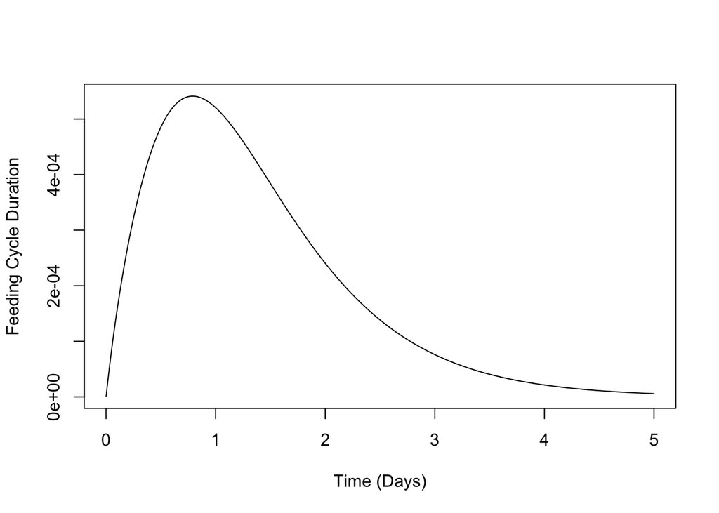

```r
R2R_pdf = diff(R2)/max(R2)
tt_pdf = (tt[-1]+tt[-length(tt)])/2
ix = which(tt_pdf<5)
plot(tt_pdf[ix], R2R_pdf[ix], type = "l", xlab = "Time (Days)", ylab = "Feeding Cycle Duration")
```

```r
MBDETES_cohort_ODE = function(t,X,P){with(as.list(c(P,X)),{
  dF = P_RF*R/tR + P_OF*O/tO + P_BF*B/tB - (1-P_FF)*FF/tF
  dB = P_RB*R/tR + P_OB*O/tO + P_FB*FF/tF - (1-P_BB)*B/tB
  dR = P_BR*B/tB-R/tR
  dL = P_RL*R/tR + P_OL*O/tO - (1-P_LL)*L/tL
  dO = P_RO*R/tR + P_LO*L/tL - (1-P_OO)*O/tO
  dOO = (P_OF + P_OB)*O/tO
  dRR = P_BR*B/tB
  list(c(dF,dB,dR,dL,dO,dOO,dRR))
})}

MBDETES_cohort_solve = function(PAR, pF=1, mxT=100, dt=0.001){
  inits = c(FF=pF,B=1-pF,R=0,L=0,O=0,OO=0,RR=0)
  tm = seq(0,mxT,by=dt)
  data.frame(lsoda(inits,tm,MBDETES_cohort_ODE,PAR,atol=1e-10))
}
cohort=MBDETES_cohort_solve(PAR,pF=.5,dt=0.01)
tt=cohort[,1]
alive = rowSums(cohort[,2:6])
eggs = cohort[,7]
bloodmeals = cohort[,8]

highSum=-sum(diff(alive)*tt[-1])
lowSum=-sum(diff(alive)*tt[-length(tt)])
(lowSum+highSum)/2
```

```
## [1] 9.85025
```

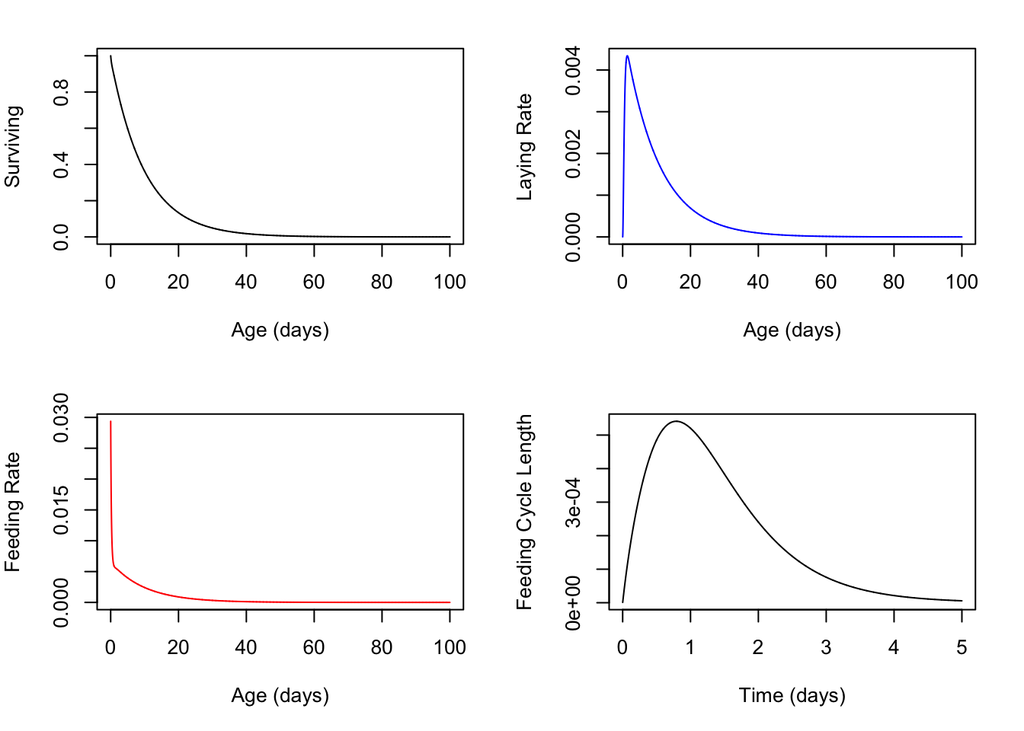

```r
par(mfrow=c(2,2), mar = c(5,4,2,2))
plot(tt, alive, type = "l", xlab = "Age (days)", ylab = "Surviving")
#lines(tt, exp(-tt/9.78), col = "red")
plot(tt[-1], diff(eggs), col = "blue", type = "l", xlab = "Age (days)", ylab= "Laying Rate")
plot(tt[-1], diff(bloodmeals), col = "red", type = "l", xlab = "Age (days)", ylab = "Feeding Rate")
plot(tt_pdf[ix], R2R_pdf[ix], type = "l", xlab = "Time (days)", ylab = "Feeding Cycle Length")
```